# Replicando análisis de mortalidad de COVID para Chile

El siguiente notebook tiene como objetivo replicar el análisis realizado por The Economist para la realidad de Chile

Este análisis está inspirado en la publicación realizada por The Economist que pueden encontrar en **[AQUÍ](https://www.economist.com/graphic-detail/2020/04/03/covid-19s-death-toll-appears-higher-than-official-figures-suggest)**

[figure not shown]

## Datos históricos de mortalidad

La búsqueda de datos sobre mortalidad resultó ser una difícil tarea, de hecho la data histórica desagregada a nivel granular de defunción anonimizada solo llega hasta 2017. Esto porque la data de defunciones que debe ser publicada por el Instituto Nacional de Estadísticas (INE) y por el Departamento de Estadísticas de Información de Salud (DEIS), tarda años en ser procesada y publicada.

Para este análisis los datos fueron obtenidos desde la página **[DEIS](https://deis.minsal.cl/#datosabiertos)**, específicamente de la sección datos abiertos, el dataset se llama **["DEF_1990-2017"](https://repositoriodeis.minsal.cl/DatosAbiertos/Vitales/DEF_1990-2017.rar)**

A continuación se puede apreciar una muestra de los datos que contiene este dataset:

|  | ID_FALLECIDO | DIA_DEF | MES_DEF | ANO_DEF | FECHA_DEF | SEXO | GLOSA_SEXO | DIA_NAC | MES_NAC | ANO_NAC | FECHA_NACIMIENTO | EDAD_CANT | EDAD_TIPO | GLOSA_EDAD_TIPO | EST_CIVIL | GLOSA_EST_CIVIL | CURSO_INS | NIVEL_INS | GLOSA_NIVEL_INS | ACTIVIDAD | GLOSA_ACTIVIDAD | OCUPACION | GLOSA_OCUPACION | CATEGORIA | GLOSA_CATEGORIA | ANO_INSCR | LOCAL_DEF | GLOSA_LOCAL_DEF | REG_RES | … |
| --- | --- | --- | --- | --- | --- | --- | --- | --- | --- | --- | --- | --- | --- | --- | --- | --- | --- | --- | --- | --- | --- | --- | --- | --- | --- | --- | --- | --- | --- | --- |
| 0 | DD1E27F3C672A48FC03201517F359219D583F557 | 16.0 | 6.0 | 1998 | 1998-06-16 | 1.0 | Hombre | 29.0 | 12.0 | 1906.0 | 1906-12-29 | 92 | 1.0 | Edad en años | 2.0 | Casado | 5.0 | 1.0 | Superior | 0.0 | Inactivo | 5 | Jubilado | 0.0 | Inactivo | NaN | 2.0 | Casa Habitación | 13 | … |
| 1 | C3D055440B5B37EFD89C04C7975F6A081CE43781 | 3.0 | 7.0 | 2007 | 2007-07-03 | 1.0 | Hombre | 14.0 | 1.0 | 1915.0 | 1915-01-14 | 92 | 1.0 | Edad en años | 3.0 | Viudo | 6.0 | 3.0 | Secundaria | 0.0 | Inactivo | 5 | Jubilado | 0.0 | Inactivo | NaN | 2.0 | Casa Habitación | 13 | … |
| 2 | 578A350EE1B1A24CADAC566A79F16130B27E3B25 | 6.0 | 9.0 | 2006 | 2006-09-06 | 1.0 | Hombre | 25.0 | 7.0 | 1911.0 | 1911-07-25 | 95 | 1.0 | Edad en años | 2.0 | Casado | 6.0 | 4.0 | Básico o Primario | 0.0 | Inactivo | 5 | Jubilado | 0.0 | Inactivo | NaN | 3.0 | Otro | 13 | … |
| 3 | B70FD857D03AC268148A7190E2824A2C4DEE42DA | 13.0 | 6.0 | 1998 | 1998-06-13 | 1.0 | Hombre | 18.0 | 3.0 | 1915.0 | 1915-03-18 | 83 | 1.0 | Edad en años | 3.0 | Viudo | 4.0 | 4.0 | Básico o Primario | 0.0 | Inactivo | 5 | Jubilado | 0.0 | Inactivo | NaN | 2.0 | Casa Habitación | 13 | … |
| 4 | FD097AB8DC5DF2F04F1DE1E84936BEA2D6273C87 | 8.0 | 7.0 | 2007 | 2007-07-08 | 1.0 | Hombre | 19.0 | 6.0 | 1913.0 | 1913-06-19 | 94 | 1.0 | Edad en años | 2.0 | Casado | 6.0 | 3.0 | Secundaria | 0.0 | Inactivo | 5 | Jubilado | 0.0 | Inactivo | NaN | 2.0 | Casa Habitación | 13 | … |

## Datos de Población

Los datos de población corresponden a una proyección de realizada por el INE en el informe "CHILE Proyecciones y Estimaciones de Poblacion Total del Pais 1950-2050", el cual se puede encontrar **[AQUÍ](http://estadistica.ssmso.cl/downloads/proyecciones/CHILE-Proyecciones-y-Estimaciones-de-Poblacion-Total-del-Pais-1950-2050.pdf)**

## Tratamiento de datos históricos y cálculo de defunciones por cada 100.000 habitantes

Ya con la información de población, es posible estimar la tasa de mortalidad por cada 100.000 habitantes, y dado que tenemos datos desde 1990 generé una serie semanal de datos (podría ser diaria pero más delante se justificará porque no fue así), promediando las defunciones semanales de cada año, y calculé un intervalo de confianza para determinar posteriormente si la serie semanal 2020 tiene diferencias significativas.

Esta sería una muestra del dataframe, donde:

- mean: promedio semanal de tasa de defunción por cada 100.000 habitantes
- hi = limite superior de intervalo de confianza (95%)
- low = limite inferior de intervalo de confianza (95%)

|  | week | mean | count | std | hi | low |
| --- | --- | --- | --- | --- | --- | --- |
| 0 | 1 | 10.069146 | 28 | 2.096929 | 10.845860 | 9.292433 |
| 1 | 2 | 9.792310 | 28 | 0.472799 | 9.967437 | 9.617183 |
| 2 | 3 | 9.710809 | 28 | 0.575868 | 9.924113 | 9.497504 |
| 3 | 4 | 9.616349 | 28 | 0.578925 | 9.830786 | 9.401912 |
| 4 | 5 | 9.478948 | 28 | 0.469246 | 9.652759 | 9.305136 |

## Serie de defunciones 2020

Lamentablemente aún no existen estadísticas diarias sobre defunciones reales, sin embargo, a partir del 15/05/2020 el Registro Civil liberó el dato de la cantidad diaria de inscripciones de defunción, que como ellos señalan en su web "Cabe señalar, que la fecha de inscripción, no representa la fecha de defunción de una persona.", pero que podría servir como proxy de las defunciones reales, por ello hice una comparación de las defunciones reales versus las inscritas para establecer si es posible hacer esta aproximación. Asimismo, quiero hacer hincapié en que la información liberada está incompleta, ya que los certificados tienen **fecha de defunción**, pero esto **NO FUE PUBLICADO**, siendo que este dato genera una mejor estimación de la realidad.

```
Según datos históricos, entre 2010 y 2017 hubo 805447 fallecidos, mientras que de acuerdo a los Certificados hubo 809966 defunciones inscritas, lo anterior representa un 0.56% de sobreestimación si usamos el certificado sobre las defunciones reales
```

Al menos en términos gruesos, las cifras son similares y el error pareciera no ser significativo.

Ahora vamos a visualizar el comportamiento diario para ver si podemos realizar el análisis con esa temporalidad

*Gráfico 1: Comparación entre series diarias de defunciones, real versus las inscritas 2010 - 2017*

```
<function matplotlib.pyplot.show(*args, **kw)>
```

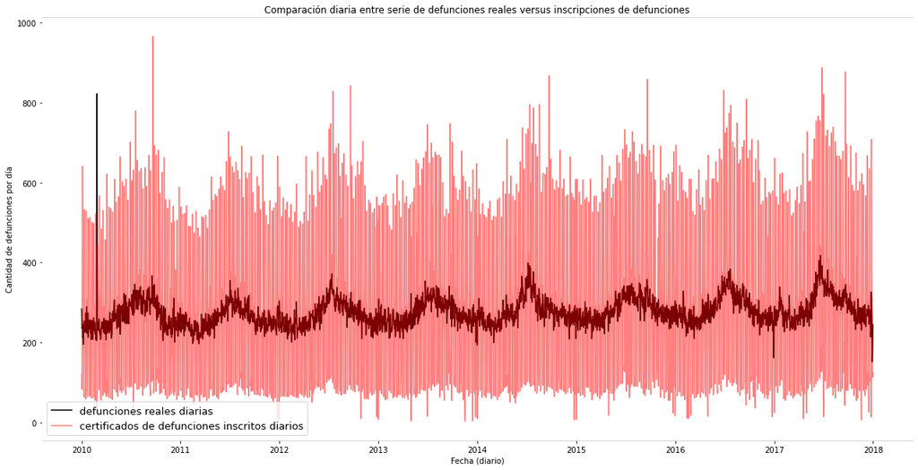

Se puede apreciar en el gráfico 1 que los comportamientos de las series diarias son bastante disímiles, por lo que no es posible usar la data como proxy a este nivel, pues la aproximación presentaría mucho ruido. Frente a esta problemática, decidí pasar al siguiente nivel de agregación temporal, **semana**.

*Gráfico 2: Comparación entre series semanales de defunciones, real versus las inscritas 2010 - 2017*

```
<function matplotlib.pyplot.show(*args, **kw)>
```

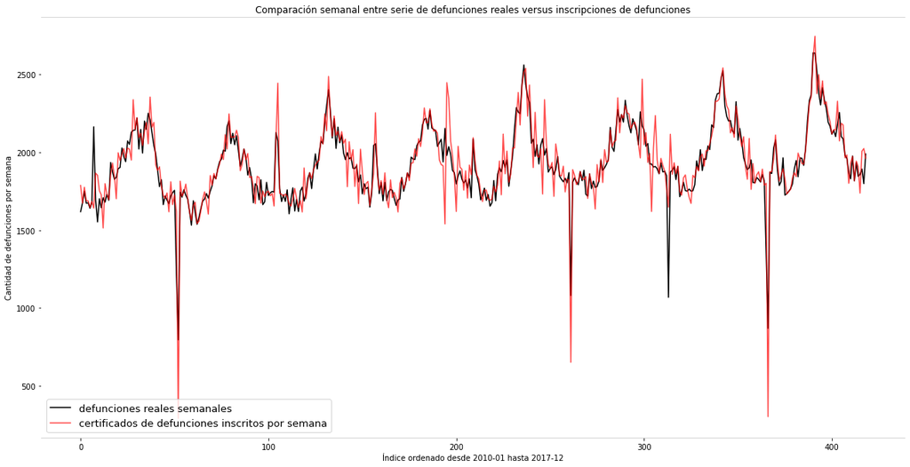

Esta vez vemos que en general tenemos comportamientos mucho más parecidos entre ambas series, por lo que haremos una prueba t para ver si podemos usar la proxy

```
Ttest_indResult(statistic=array([-0.6472622]), pvalue=array([0.51763995]))
```

Obtenemos un alto p-value, por lo que no se puede descartar que sus medias sean iguales. Calcularemos el promedio del error porcentual absoluto para tener una idea del error que podríamos estar cometiendo con la estimación.

```
mean       4.631630
median     2.296211
std       13.372957
Name: diff, dtype: float64
90th percentil: 8.392508948726423
```

## Serie de datos de defunciones por COVID-19

La serie de datos de defunciones por COVID-19 se extrae desde el repositorio del [Ministerio de Ciencia](https://github.com/MinCiencia/Datos-COVID19/tree/master/output) para COVID, específicamente el [producto 5](https://github.com/MinCiencia/Datos-COVID19/tree/master/output/producto5). Se agradece que hayan automatizado esta serie, pues en las primeras versiones de este análisis, lo tuve que hacer extrayendo desde el informe en PDF, usando tabula-py, y se rompía cada vez que cambiaban la tabla 1.

A continuación podemos ver una muestra de esta serie:

|  | MuertesCOVID | Fecha |
| --- | --- | --- |
| 0 | 0 | 2020-01-01 |
| 1 | 0 | 2020-01-02 |
| 2 | 0 | 2020-01-03 |
| 3 | 0 | 2020-01-04 |
| 4 | 0 | 2020-01-05 |

## Gráfico

A continuación se presenta el gráfico con las tres series ya expuestas, presentadas en términos de defunciones diarias por cada 100.000 habitantes.

*Gráfico 3: Evolución de defunciones promedio por cada 100.000 vs COVID-19 versus 2020 (ESTIMACION EN BASE A CERTIFICADO)*

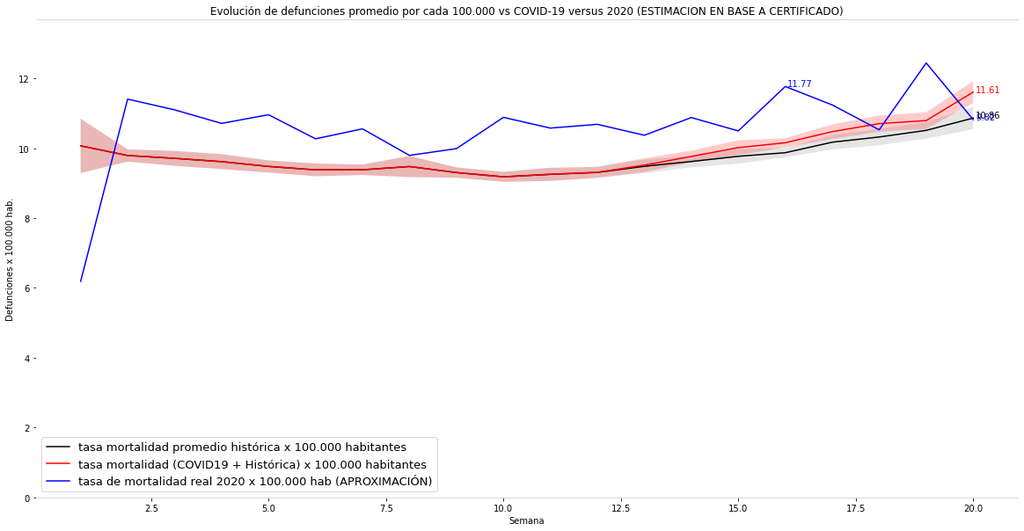

### ¿Cómo interpretar el gráfico?

Además en gris se pueden ver los límites del intervalo de confianza de 95% para la serie histórica. En rojo claro, el intervalo de confianza para la serie combinada de histórico + COVID-19

#### Como se puede apreciar se presentan diferencias significativas entre la serie real 2020 versus la combinada, el problema es que, el error que tenemos de 8,3% no explicaría esta diferencia, sin embargo, como vemos este año han habido inscripciones de defunciones semanales en una mayor cantidad que las defunciones reales semanales promedio, sin embargo estas no van al alza, sino que han sido superiores durante gran parte de las semanas del año, y esto podría estar explicado porque la serie histórica solo llega hasta 2017. Para evitar la distorsión de comparar un proxy con un dato real hice uso de la serie histórica de certificados y es lo que presenta a continuación

### Análisis usando como base histórica los datos de Certificados

A modo de ejercicio analítico, y con la finalidad de eliminar la distorsión que se produce entre las series histórica real y la de certificados, realicé el mismo gráfico reemplazando la serie histórica de defunciones reales por la serie histórica de certificados

*Gráfico 4: Evolución de inscripciones de defunciones promedio (2010 -2019) por cada 100.000 vs COVID-19 versus 2020 (Datos de certificado de defunción)*

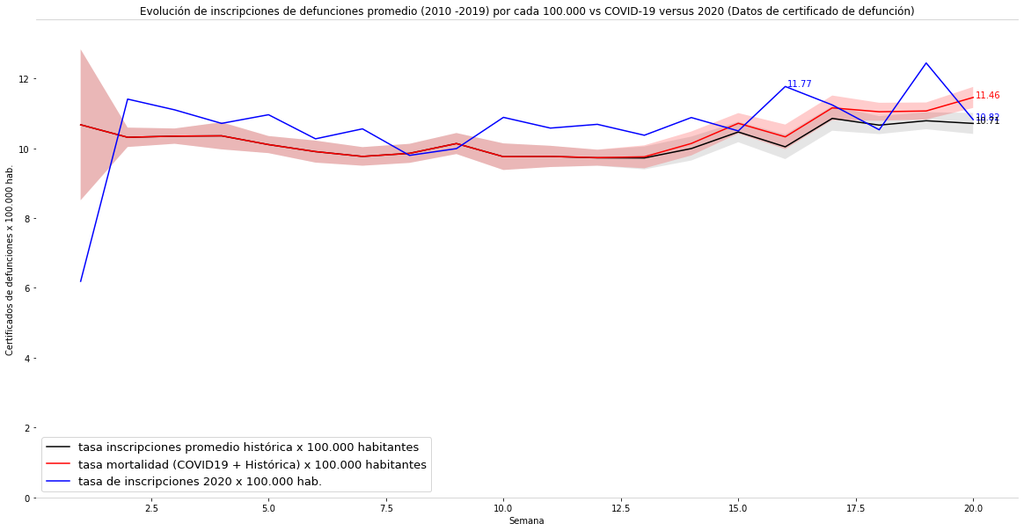

Como vemos en el gráfico 4, las series se acercaron, si lo comparamos con el gráfico 3, sin embargo 2020 sigue estando por sobre la serie histórica en varias semanas y aunque no pareciera tener una tendencia al alza, es muy prematuro aseverarlo con certeza.

## ¿Por qué es importante este gráfico?

https://www.ons.gov.uk/peoplepopulationandcommunity/birthsdeathsandmarriages/deaths/datasets/weeklyprovisionalfiguresondeathsregisteredinenglandandwales

```
('2020.xlsx', <http.client.HTTPMessage at 0x1e09ff181c8>)
```

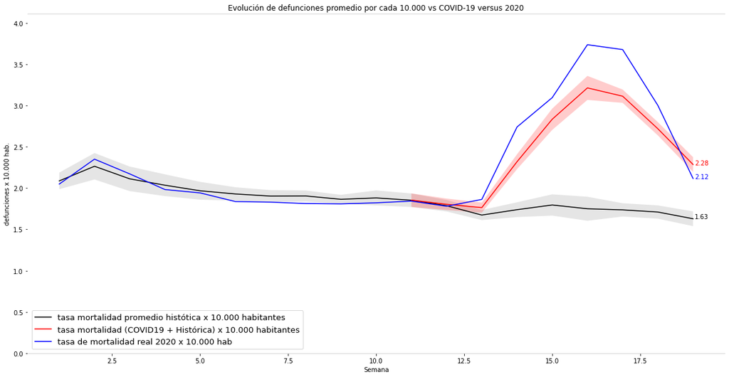

Como se aprecia en el gráfico la diferencia entre la suma de las series COVID + Histórica (linea roja) y defunciones reales 2020, es significativa. Frente a esto nos surge las dudas:

- ¿A qué se debe esta diferencia?
- ¿Se están contabilizando correctamente las defunciones por COVID?
- ¿El factor COVID ha incidido en la muerte por otras causas?

Y la pregunta principal:

- **¿Está pasando esto en Chile?**

  ### Aparentemente no, pero esto sigue siendo un aproximación a los datos reales, que esperemos sean liberados.